# FIN503 Final Project: Predicting Ford Motor Company Stock Returns Using Multi-Factor Regression

Variable Selection, Diagnostic Testing, and Out-of-Sample Evaluation

Vincent Ngai and Yashvi Bhatt

2025-12-07

```r
# ── Package Loading ────────────────────────────────────────────────────────────
library(dplyr)      # Data manipulation
library(MASS)       # Stepwise AIC (stepAIC)
library(leaps)      # Best-subset selection (Mallows' Cp)
library(car)        # VIF, qqPlot
library(lmtest)     # Breusch-Pagan heteroskedasticity test
library(estimatr)   # Heteroskedasticity-consistent (robust) standard errors
library(ggplot2)    # Plotting
library(knitr)      # Table formatting
library(kableExtra) # Enhanced HTML tables
library(corrplot)   # Correlation heatmap
```

# 1 Introduction

This project investigates whether the monthly stock returns of **Ford Motor Company** can be systematically predicted using a combination of macroeconomic indicators, market-level variables, and commodity prices. Using monthly data spanning January 2004 through November 2025, we build and compare several linear regression models, apply formal model-selection criteria, conduct regression diagnostics, and evaluate out-of-sample forecasting performance on a 23-month holdout period (January 2024 – November 2025).

The central research question is: **Which subset of macroeconomic and market predictors best explains Ford’s monthly stock returns, and how well does the chosen model perform on unseen data?**

Our analysis proceeds as follows: (1) data loading and feature engineering; (2) exploratory analysis; (3) full-model estimation; (4) variable selection via stepwise AIC and Mallows’ Cp; (5) regression diagnostics including multicollinearity (VIF), normality of residuals (Shapiro-Wilk), and heteroskedasticity (Breusch-Pagan); (6) robust standard errors; and (7) out-of-sample prediction with RMSE, MAE, and OOS R² metrics.

# 2 Data Loading

The raw dataset contains 263 monthly observations from January 2004 through November 2025.

```r
df <- read.csv("FIN503_project_data.csv")
cat("Dimensions:", nrow(df), "rows ×", ncol(df), "columns\n")
```

```
## Dimensions: 263 rows × 14 columns
```

```r
cat("Variables:", paste(names(df), collapse = ", "), "\n")
```

```
## Variables: Date, usd_euro_ex, gold, oil, FIBOR, Confidence.Index, S.and.P, market_p_to_b, div_yield, Ford, market_eps, Volatility, X10y_treasury, R_f
```

**Variable Descriptions:**

| Raw Variable | Description |
| --- | --- |
| `S.and.P` | S&P 500 Index level |
| `Ford` | Ford Motor Company stock price |
| `gold` | Gold spot price (USD/oz) |
| `oil` | Crude oil price (USD/bbl) |
| `usd_euro_ex` | USD/EUR exchange rate |
| `FIBOR` | Frankfurt Interbank Offered Rate |
| `Confidence.Index` | Barron’s Confidence Index |
| `market_p_to_b` | S&P 500 Price-to-Book ratio |
| `div_yield` | S&P 500 dividend yield (%) |
| `market_eps` | S&P 500 earnings per share |
| `Volatility` | S&P 500 implied volatility (VIX, %) |
| `X10y_treasury` | 10-Year US Treasury yield (%) |
| `R_f` | Risk-free rate (%) |

# 3 Feature Engineering

We transform the raw price and rate data into economically meaningful predictors. Asset prices become monthly returns, percentage yields are converted to decimal form, and valuation ratios are derived from their reciprocals. The first observation is dropped from the training set because lag-based return calculations are undefined for the initial row.

```r
df <- df %>%
  mutate(
    # Valuation ratios
    div_to_price      = div_yield / 100,
    earnings_to_price = market_eps / S.and.P,
    book_to_market    = 1 / market_p_to_b,

    # Monthly asset returns (price relative minus 1)
    gold_return   = (gold        / lag(gold))        - 1,
    oil_return    = (oil         / lag(oil))          - 1,
    dol_eu_change = (usd_euro_ex / lag(usd_euro_ex)) - 1,
    ford_return   = (Ford        / lag(Ford))         - 1,
    market_return = (S.and.P     / lag(S.and.P))      - 1,

    # Market risk premium and realized variance
    excess_return   = market_return - R_f / 100,
    market_variance = (Volatility / 100)^2,

    # Interest rates converted to decimal form
    X10y_treasury = X10y_treasury / 100,
    FIBOR         = FIBOR         / 100
  ) %>%
  dplyr::select(
    Date, FIBOR, Confidence.Index, X10y_treasury, div_to_price,
    earnings_to_price, book_to_market, gold_return, oil_return,
    dol_eu_change, ford_return, excess_return, market_variance
  )
```

## Train / Test Split

We use a **time-series aware split** that respects the chronological ordering of observations. The training set covers February 2004 through December 2023 (239 months), and the holdout set covers January 2024 through November 2025 (23 months). This design prevents look-ahead bias: all model parameters are estimated exclusively on past data, and performance is evaluated on a genuinely unseen future period.

```r
training_df <- df[2:240, ]   # In-sample:  Feb 2004 – Dec 2023 (239 obs)
predict_df  <- df[241:263, ] # Out-of-sample: Jan 2024 – Nov 2025 (23 obs)

cat("Training observations:", nrow(training_df), "\n")
```

```
## Training observations: 239
```

```r
cat("Holdout  observations:", nrow(predict_df),  "\n")
```

```
## Holdout  observations: 23
```

# 4 Exploratory Data Analysis

## 4.1 Summary Statistics

```r
training_df %>%
  dplyr::select(-Date) %>%
  summary()
```

```
##      FIBOR           Confidence.Index X10y_treasury      div_to_price
##  Min.   :-0.005730   Min.   : 25.30   Min.   :0.00529   Min.   :0.2984
##  1st Qu.:-0.003135   1st Qu.: 71.80   1st Qu.:0.01990   1st Qu.:0.3374
##  Median : 0.003390   Median : 98.30   Median :0.02716   Median :0.3752
##  Mean   : 0.011116   Mean   : 92.42   Mean   :0.02874   Mean   :0.4185
##  3rd Qu.: 0.021330   3rd Qu.:108.85   3rd Qu.:0.03839   3rd Qu.:0.4536
##  Max.   : 0.052770   Max.   :137.90   Max.   :0.05138   Max.   :0.9407
##  earnings_to_price book_to_market    gold_return          oil_return
##  Min.   :0.02318   Min.   :0.2031   Min.   :-0.168896   Min.   :-0.542449
##  1st Qu.:0.04239   1st Qu.:0.3004   1st Qu.:-0.022791   1st Qu.:-0.056415
##  Median :0.04959   Median :0.3522   Median : 0.003688   Median : 0.015125
##  Mean   :0.04937   Mean   :0.3549   Mean   : 0.008028   Mean   : 0.009582
##  3rd Qu.:0.05673   3rd Qu.:0.4123   3rd Qu.: 0.038165   3rd Qu.: 0.073774
##  Max.   :0.07607   Max.   :0.6029   Max.   : 0.130137   Max.   : 0.883758
##  dol_eu_change         ford_return        excess_return
##  Min.   :-0.0969344   Min.   :-0.578846   Min.   :-0.172325
##  1st Qu.:-0.0150677   1st Qu.:-0.056102   1st Qu.:-0.034174
##  Median :-0.0002674   Median :-0.003409   Median :-0.003590
##  Mean   :-0.0001594   Mean   : 0.008068   Mean   :-0.006752
##  3rd Qu.: 0.0169140   3rd Qu.: 0.053578   3rd Qu.: 0.021580
##  Max.   : 0.1008589   Max.   : 1.273764   Max.   : 0.125744
##  market_variance
##  Min.   :0.009044
##  1st Qu.:0.018442
##  Median :0.028090
##  Mean   :0.044059
##  3rd Qu.:0.052464
##  Max.   :0.358681
```

## 4.2 Correlation Heatmap

Before building models, we examine pairwise correlations across all variables to identify potential multicollinearity and relationships with the target variable (`ford_return`).

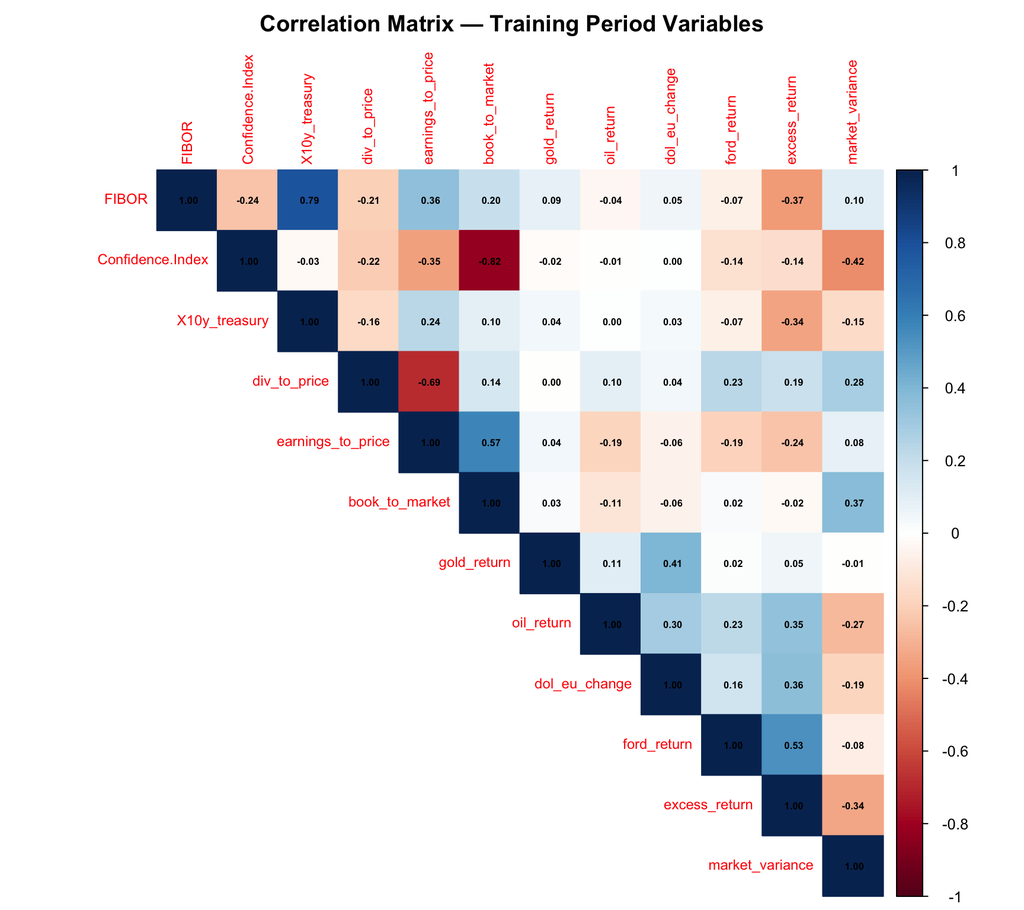

```r
cor_mat <- training_df %>%
  dplyr::select(-Date) %>%
  cor(use = "complete.obs")

corrplot(
  cor_mat,
  method      = "color",
  type        = "upper",
  tl.cex      = 0.75,
  addCoef.col = "black",
  number.cex  = 0.52,
  title       = "Correlation Matrix — Training Period Variables",
  mar         = c(0, 0, 2, 0)
)
```

# 5 Model Building

## 5.1 Full Model (Kitchen Sink)

We begin by regressing Ford’s monthly return on all 11 candidate predictors. This full model serves as a baseline and provides the input required for the variable-selection algorithms below.

```r
big_reg <- lm(
  ford_return ~ FIBOR + Confidence.Index + X10y_treasury + div_to_price +
    earnings_to_price + book_to_market + gold_return + oil_return +
    dol_eu_change + excess_return + market_variance,
  data = training_df
)
summary(big_reg)
```

```
##
## Call:
## lm(formula = ford_return ~ FIBOR + Confidence.Index + X10y_treasury +
##     div_to_price + earnings_to_price + book_to_market + gold_return +
##     oil_return + dol_eu_change + excess_return + market_variance,
##     data = training_df)
##
## Residuals:
##      Min       1Q   Median       3Q      Max
## -0.44343 -0.05367 -0.00773  0.03708  0.97958
##
## Coefficients:
##                     Estimate Std. Error t value Pr(>|t|)
## (Intercept)       -0.2031252  0.1599368  -1.270   0.2054
## FIBOR              0.9463998  0.9393095   1.008   0.3147
## Confidence.Index   0.0001578  0.0006738   0.234   0.8151
## X10y_treasury      1.4104001  1.2845141   1.098   0.2734
## div_to_price       0.2869724  0.2081409   1.379   0.1693
## earnings_to_price  2.4499171  3.1938280   0.767   0.4438
## book_to_market    -0.2831422  0.3607360  -0.785   0.4333
## gold_return       -0.0019502  0.1729336  -0.011   0.9910
## oil_return         0.0669278  0.0750397   0.892   0.3734
## dol_eu_change     -0.4643328  0.3534308  -1.314   0.1902
## excess_return      2.0212230  0.2435617   8.299 9.41e-15 ***
## market_variance    0.4071930  0.2409433   1.690   0.0924 .
## ---
## Signif. codes:  0 '***' 0.001 '**' 0.01 '*' 0.05 '.' 0.1 ' ' 1
##
## Residual standard error: 0.1169 on 227 degrees of freedom
## Multiple R-squared:  0.3458, Adjusted R-squared:  0.3141
## F-statistic: 10.91 on 11 and 227 DF,  p-value: 4.126e-16
```

The full model explains a substantial share of in-sample variation, but several predictors are not individually significant — motivating the use of formal variable selection.

## 5.2 Variable Selection: Stepwise AIC

Stepwise regression using the **Akaike Information Criterion (AIC)** iteratively adds and removes predictors, retaining only those that improve the penalized log-likelihood. Lower AIC indicates a better balance between fit and model complexity.

```r
# Run stepwise AIC (both directions); suppress per-step output
step_result <- stepAIC(big_reg, direction = "both", trace = FALSE)
```

```r
summary(step_result)
```

```
##
## Call:
## lm(formula = ford_return ~ X10y_treasury + div_to_price + excess_return +
##     market_variance, data = training_df)
##
## Residuals:
##      Min       1Q   Median       3Q      Max
## -0.43375 -0.05299 -0.00623  0.03651  0.99329
##
## Coefficients:
##                 Estimate Std. Error t value Pr(>|t|)
## (Intercept)     -0.11118    0.03489  -3.186  0.00164 **
## X10y_treasury    2.25666    0.74610   3.025  0.00277 **
## div_to_price     0.11976    0.06364   1.882  0.06111 .
## excess_return    1.87366    0.19913   9.409  < 2e-16 ***
## market_variance  0.38387    0.19218   1.997  0.04694 *
## ---
## Signif. codes:  0 '***' 0.001 '**' 0.01 '*' 0.05 '.' 0.1 ' ' 1
##
## Residual standard error: 0.1164 on 234 degrees of freedom
## Multiple R-squared:  0.3318, Adjusted R-squared:  0.3204
## F-statistic: 29.05 on 4 and 234 DF,  p-value: < 2.2e-16
```

The stepwise AIC algorithm selects a **4-variable model**:

$$\hat{R}^{Ford}_t = \beta_0 + \beta_1 \cdot \text{DivYield}_t + \beta_2 \cdot \text{MktVar}_t + \beta_3 \cdot \text{10yYield}_t + \beta_4 \cdot \text{ExcessReturn}_t + \varepsilon_t$$

```r
AIC_reg <- lm(
  ford_return ~ div_to_price + market_variance + X10y_treasury + excess_return,
  data = training_df
)
summary(AIC_reg)
```

```
##
## Call:
## lm(formula = ford_return ~ div_to_price + market_variance + X10y_treasury +
##     excess_return, data = training_df)
##
## Residuals:
##      Min       1Q   Median       3Q      Max
## -0.43375 -0.05299 -0.00623  0.03651  0.99329
##
## Coefficients:
##                 Estimate Std. Error t value Pr(>|t|)
## (Intercept)     -0.11118    0.03489  -3.186  0.00164 **
## div_to_price     0.11976    0.06364   1.882  0.06111 .
## market_variance  0.38387    0.19218   1.997  0.04694 *
## X10y_treasury    2.25666    0.74610   3.025  0.00277 **
## excess_return    1.87366    0.19913   9.409  < 2e-16 ***
## ---
## Signif. codes:  0 '***' 0.001 '**' 0.01 '*' 0.05 '.' 0.1 ' ' 1
##
## Residual standard error: 0.1164 on 234 degrees of freedom
## Multiple R-squared:  0.3318, Adjusted R-squared:  0.3204
## F-statistic: 29.05 on 4 and 234 DF,  p-value: < 2.2e-16
```

## 5.3 Variable Selection: Mallows’ Cp

**Mallows’ Cp** is a bias-variance tradeoff criterion. For each candidate model of size $p$, we prefer specifications where $C_p \approx p + 1$ (intercept included). Models with $C_p$ substantially above $p + 1$ suffer from omitted-variable bias; those well below may be overfitted.

```r
# Remove ford_return (col 11) and Date (col 1) to form the predictor matrix
temp    <- training_df[, -11]
temp    <- temp[, -1]
x       <- as.matrix(temp)
names_x <- c("FIBOR", "Conf", "10y", "div", "ep", "bm",
              "goldr", "oilr", "ex", "ret", "var")

leaps.fit <- leaps(
  y     = training_df$ford_return,
  x     = x,
  names = names_x,
  nbest = 1
)

# Build and display Cp table
cp_table <- cbind(as.data.frame(leaps.fit$which), Cp = round(leaps.fit$Cp, 2))
kable(cp_table,
      caption = "Mallows' Cp by Model Size — Best Model per Size Class") %>%
  kable_styling(bootstrap_options = c("striped", "hover"), full_width = FALSE,
                font_size = 12)
```

Mallows’ Cp by Model Size — Best Model per Size Class

| FIBOR | Conf | 10y | div | ep | bm | goldr | oilr | ex | ret | var | Cp |
| --- | --- | --- | --- | --- | --- | --- | --- | --- | --- | --- | --- |
| FALSE | FALSE | FALSE | FALSE | FALSE | FALSE | FALSE | FALSE | FALSE | TRUE | FALSE | 13.65 |
| TRUE | FALSE | FALSE | FALSE | FALSE | FALSE | FALSE | FALSE | FALSE | TRUE | FALSE | 9.05 |
| TRUE | FALSE | FALSE | TRUE | FALSE | FALSE | FALSE | FALSE | FALSE | TRUE | FALSE | 2.37 |
| FALSE | FALSE | TRUE | TRUE | FALSE | FALSE | FALSE | FALSE | FALSE | TRUE | TRUE | 2.84 |
| FALSE | FALSE | TRUE | TRUE | FALSE | TRUE | FALSE | FALSE | FALSE | TRUE | TRUE | 3.86 |
| TRUE | TRUE | FALSE | TRUE | FALSE | FALSE | FALSE | FALSE | TRUE | TRUE | TRUE | 4.54 |
| TRUE | TRUE | TRUE | TRUE | FALSE | FALSE | FALSE | FALSE | TRUE | TRUE | TRUE | 5.52 |
| TRUE | TRUE | TRUE | TRUE | FALSE | FALSE | FALSE | TRUE | TRUE | TRUE | TRUE | 6.64 |
| TRUE | FALSE | TRUE | TRUE | TRUE | TRUE | FALSE | TRUE | TRUE | TRUE | TRUE | 8.05 |
| TRUE | TRUE | TRUE | TRUE | TRUE | TRUE | FALSE | TRUE | TRUE | TRUE | TRUE | 10.00 |
| TRUE | TRUE | TRUE | TRUE | TRUE | TRUE | TRUE | TRUE | TRUE | TRUE | TRUE | 12.00 |

The Cp criterion selects the **3-variable model** containing FIBOR, dividend-to-price ratio, and excess market return — the point at which Cp is closest to $p + 1 = 4$.

```r
CP_reg <- lm(ford_return ~ FIBOR + div_to_price + excess_return,
             data = training_df)
summary(CP_reg)
```

```
##
## Call:
## lm(formula = ford_return ~ FIBOR + div_to_price + excess_return,
##     data = training_df)
##
## Residuals:
##      Min       1Q   Median       3Q      Max
## -0.37412 -0.05376 -0.00726  0.03049  1.02258
##
## Coefficients:
##               Estimate Std. Error t value Pr(>|t|)
## (Intercept)   -0.07096    0.02757  -2.574  0.01068 *
## FIBOR          1.50098    0.50075   2.997  0.00301 **
## div_to_price   0.17674    0.05977   2.957  0.00342 **
## excess_return  1.72200    0.17654   9.754  < 2e-16 ***
## ---
## Signif. codes:  0 '***' 0.001 '**' 0.01 '*' 0.05 '.' 0.1 ' ' 1
##
## Residual standard error: 0.1165 on 235 degrees of freedom
## Multiple R-squared:  0.3275, Adjusted R-squared:  0.3189
## F-statistic: 38.14 on 3 and 235 DF,  p-value: < 2.2e-16
```

## 5.4 CAPM Benchmark

As an academic benchmark, we estimate the single-factor **Capital Asset Pricing Model (CAPM)**. Under CAPM, a stock’s return in excess of the risk-free rate is determined solely by its market beta — its sensitivity to the market risk premium. The intercept (Jensen’s alpha) is constrained to zero.

```r
CAPM <- lm(ford_return ~ 0 + excess_return, data = training_df)
summary(CAPM)
```

```
##
## Call:
## lm(formula = ford_return ~ 0 + excess_return, data = training_df)
##
## Residuals:
##      Min       1Q   Median       3Q      Max
## -0.30996 -0.04010  0.00232  0.05217  1.12877
##
## Coefficients:
##               Estimate Std. Error t value Pr(>|t|)
## excess_return   1.5603     0.1671   9.335   <2e-16 ***
## ---
## Signif. codes:  0 '***' 0.001 '**' 0.01 '*' 0.05 '.' 0.1 ' ' 1
##
## Residual standard error: 0.121 on 238 degrees of freedom
## Multiple R-squared:  0.268,  Adjusted R-squared:  0.2649
## F-statistic: 87.14 on 1 and 238 DF,  p-value: < 2.2e-16
```

## 5.5 In-Sample Model Comparison

Both selection criteria agree that the **market excess return**, **dividend-to-price ratio**, and several macroeconomic rate variables are relevant predictors, but they disagree on the precise set. We compare the two candidate models on Adjusted R² and AIC:

```r
insample_tbl <- data.frame(
  Model        = c("Full (11 vars)", "AIC-Selected (4 vars)",
                   "Cp-Selected (3 vars)", "CAPM (1 var)"),
  Adj_R2       = round(c(summary(big_reg)$adj.r.squared,
                          summary(AIC_reg)$adj.r.squared,
                          summary(CP_reg)$adj.r.squared,
                          summary(CAPM)$adj.r.squared), 4),
  AIC_val      = round(c(AIC(big_reg), AIC(AIC_reg),
                          AIC(CP_reg),  AIC(CAPM)), 2)
)

kable(insample_tbl,
      col.names = c("Model", "Adj. R²", "AIC"),
      caption   = "In-Sample Model Comparison") %>%
  kable_styling(bootstrap_options = c("striped", "hover", "bordered"),
                full_width = FALSE) %>%
  row_spec(2, bold = TRUE, background = "#d4edda")
```

In-Sample Model Comparison

| Model | Adj. R² | AIC |
| --- | --- | --- |
| Full (11 vars) | 0.3141 | -333.91 |
| AIC-Selected (4 vars) | 0.3204 | -342.86 |
| Cp-Selected (3 vars) | 0.3189 | -343.30 |
| CAPM (1 var) | 0.2649 | -328.27 |

The AIC-selected 4-variable model achieves an Adjusted R² of 0.3204, modestly outperforming the Cp-selected model (0.3189). Because the two selection criteria diverge, we break the tie using Adjusted R² and proceed with the **4-variable AIC model** as our primary specification.

# 6 Regression Diagnostics

## 6.1 Multicollinearity

We first examine pairwise scatter plots and the correlation matrix of the four selected predictors, then formally test for multicollinearity using **Variance Inflation Factors (VIF)**. A VIF above 10 indicates a problematic degree of multicollinearity.

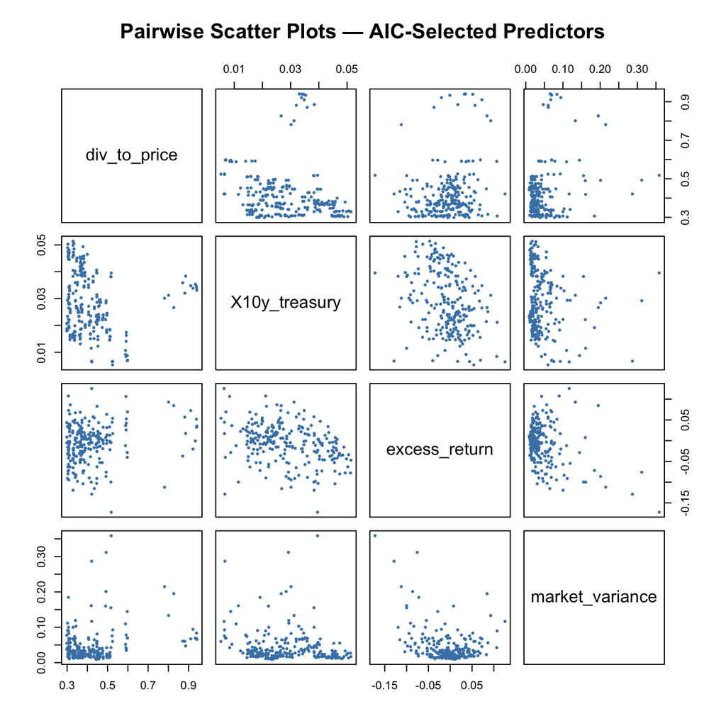

```r
temp_mc <- training_df %>%
  dplyr::select(div_to_price, X10y_treasury, excess_return, market_variance)

pairs(temp_mc,
      main   = "Pairwise Scatter Plots — AIC-Selected Predictors",
      col    = "steelblue",
      pch    = 16,
      cex    = 0.6)
```

```r
kable(round(cor(temp_mc), 4),
      caption = "Pairwise Correlations — AIC-Selected Predictors") %>%
  kable_styling(bootstrap_options = c("striped", "hover"), full_width = FALSE)
```

Pairwise Correlations — AIC-Selected Predictors

|  | div_to_price | X10y_treasury | excess_return | market_variance |
| --- | --- | --- | --- | --- |
| div_to_price | 1.0000 | -0.1632 | 0.1898 | 0.2824 |
| X10y_treasury | -0.1632 | 1.0000 | -0.3422 | -0.1538 |
| excess_return | 0.1898 | -0.3422 | 1.0000 | -0.3368 |
| market_variance | 0.2824 | -0.1538 | -0.3368 | 1.0000 |

```r
vif_vals <- vif(AIC_reg)
vif_df   <- data.frame(
  Variable = names(vif_vals),
  VIF      = round(vif_vals, 4)
)
kable(vif_df, caption = "Variance Inflation Factors — AIC-Selected Model") %>%
  kable_styling(bootstrap_options = c("striped", "hover"), full_width = FALSE)
```

Variance Inflation Factors — AIC-Selected Model

|  | Variable | VIF |
| --- | --- | --- |
| div_to_price | div_to_price | 1.2067 |
| market_variance | market_variance | 1.4293 |
| X10y_treasury | X10y_treasury | 1.2481 |
| excess_return | excess_return | 1.5018 |

All VIF values are substantially below 10. **Multicollinearity is not a concern** in the selected model, and OLS coefficient estimates are stable.

## 6.2 Normality of Residuals

We assess whether the model residuals are approximately normally distributed — a key OLS assumption for finite-sample inference. We use a QQ plot for visual inspection and the **Shapiro-Wilk test** for a formal hypothesis test.

> **Note:** This section tests the *normality* of residuals, which is distinct from heteroskedasticity. Heteroskedasticity refers to non-constant residual variance and is assessed separately in Section 6.3 using the Breusch-Pagan test.

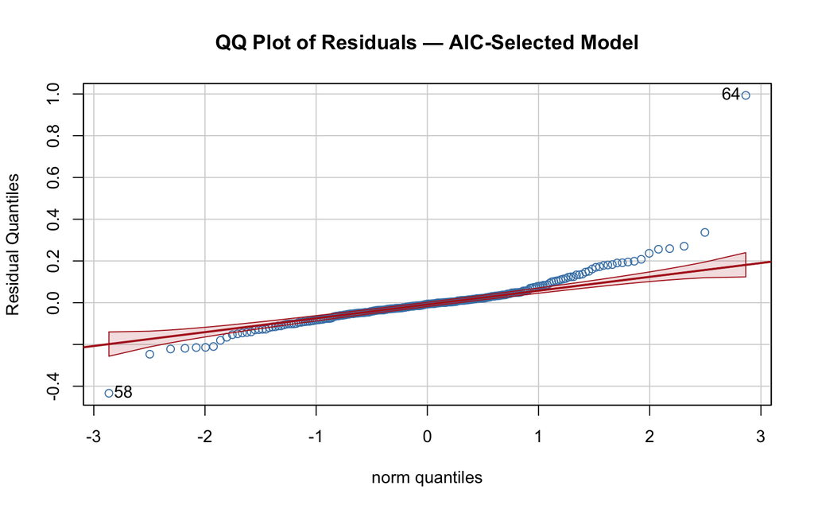

```
## 64 58
## 63 57
```

```r
qqPlot(AIC_reg$residuals,
       main = "QQ Plot of Residuals — AIC-Selected Model",
       ylab = "Residual Quantiles",
       col  = "steelblue",
       col.lines = "firebrick")
```

```r
sw_test <- shapiro.test(AIC_reg$residuals)
cat("Shapiro-Wilk Test for Normality of Residuals:\n")
```

```
## Shapiro-Wilk Test for Normality of Residuals:
```

```r
cat("  W statistic =", round(sw_test$statistic, 4), "\n")
```

```
##   W statistic = 0.8166
```

```r
cat("  p-value     =", format(sw_test$p.value, scientific = TRUE, digits = 4), "\n")
```

```
##   p-value     = 4.368e-16
```

The QQ plot shows departures from the 45° line in both tails, and the Shapiro-Wilk test rejects the null hypothesis of normality (p < 0.05). **The residuals exhibit heavier tails than a normal distribution**, a common feature of monthly financial return series driven by occasional large price shocks. This violation motivates further investigation of heteroskedasticity and the use of robust standard errors.

## 6.3 Heteroskedasticity

Non-normality alone does not imply heteroskedasticity. We test separately for **non-constant residual variance** using the **Breusch-Pagan test**, which regresses the squared residuals on the original predictors.

- $H_0$: Residual variance is constant (homoskedastic)
- $H_1$: Residual variance depends on the predictors (heteroskedastic)

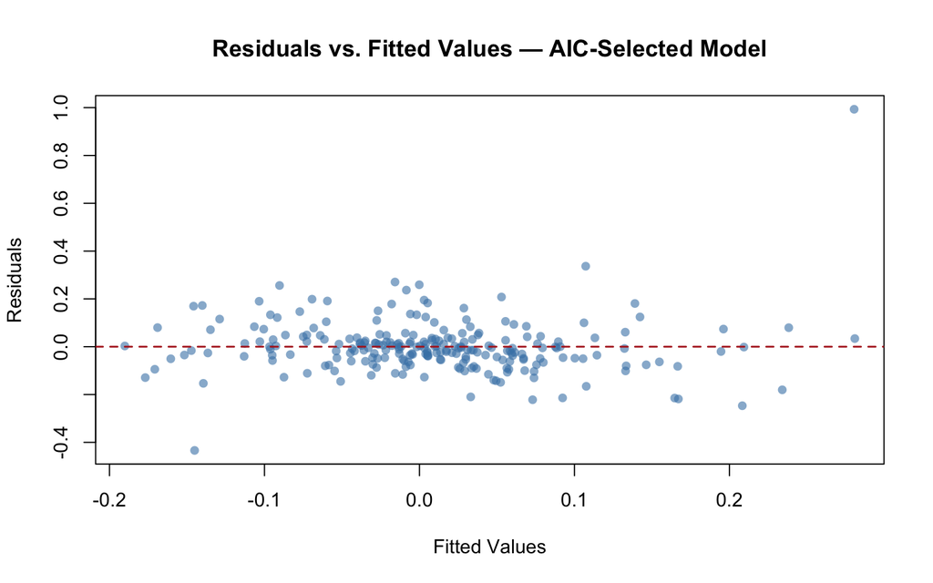

```r
# Residuals vs. Fitted Values plot: a fan or funnel shape indicates heteroskedasticity
plot(AIC_reg$fitted.values, AIC_reg$residuals,
     main = "Residuals vs. Fitted Values — AIC-Selected Model",
     xlab = "Fitted Values",
     ylab = "Residuals",
     pch  = 16,
     col  = adjustcolor("steelblue", alpha.f = 0.6))
abline(h = 0, col = "firebrick", lty = 2, lwd = 1.5)
```

```r
bp_test <- bptest(AIC_reg)
cat("Breusch-Pagan Test for Heteroskedasticity:\n")
```

```
## Breusch-Pagan Test for Heteroskedasticity:
```

```r
cat("  BP statistic =", round(bp_test$statistic, 4), "\n")
```

```
##   BP statistic = 33.6655
```

```r
cat("  df           =", bp_test$parameter, "\n")
```

```
##   df           = 4
```

```r
cat("  p-value      =", round(bp_test$p.value, 4), "\n")
```

```
##   p-value      = 0
```

> **Result:** The Breusch-Pagan test yields p = 0 < 0.05. We **reject the null hypothesis** of homoskedasticity. Residual variance is not constant, indicating the presence of heteroskedasticity. We address this by computing heteroskedasticity-consistent (HC) standard errors in Section 6.4.

## 6.4 Robust Standard Errors

To account for potential heteroskedasticity, we re-estimate the AIC model using **Heteroskedasticity-Consistent (HC) standard errors** — also known as Huber-White sandwich estimators. Robust standard errors correct the inference (standard errors, t-statistics, and p-values) without altering the point estimates.

```r
robust_AIC <- lm_robust(
  ford_return ~ div_to_price + market_variance + X10y_treasury + excess_return,
  data = training_df
)
summary(robust_AIC)
```

```
##
## Call:
## lm_robust(formula = ford_return ~ div_to_price + market_variance +
##     X10y_treasury + excess_return, data = training_df)
##
## Standard error type:  HC2
##
## Coefficients:
##                 Estimate Std. Error t value  Pr(>|t|) CI Lower CI Upper  DF
## (Intercept)      -0.1112    0.06689 -1.6622 9.781e-02 -0.24296   0.0206 234
## div_to_price      0.1198    0.09321  1.2849 2.001e-01 -0.06387   0.3034 234
## market_variance   0.3839    0.46660  0.8227 4.115e-01 -0.53539   1.3031 234
## X10y_treasury     2.2567    1.09138  2.0677 3.977e-02  0.10647   4.4069 234
## excess_return     1.8737    0.37678  4.9728 1.277e-06  1.13135   2.6160 234
##
## Multiple R-squared:  0.3318 ,    Adjusted R-squared:  0.3204
## F-statistic: 8.832 on 4 and 234 DF,  p-value: 1.171e-06
```

> **Key point:** The coefficient estimates from the robust model are identical to the OLS estimates. Only standard errors and inference statistics change. For prediction purposes, either model yields the same fitted values.

## 6.5 Coefficient Interpretation

```r
coef_df           <- as.data.frame(summary(AIC_reg)$coefficients)
colnames(coef_df) <- c("Estimate", "Std. Error", "t-value", "p-value")
coef_df_display   <- round(coef_df, 4)

kable(coef_df_display,
      caption = "AIC-Selected Model — Coefficient Estimates (OLS)") %>%
  kable_styling(bootstrap_options = c("striped", "hover"), full_width = FALSE)
```

AIC-Selected Model — Coefficient Estimates (OLS)

|  | Estimate | Std. Error | t-value | p-value |
| --- | --- | --- | --- | --- |
| (Intercept) | -0.1112 | 0.0349 | -3.1862 | 0.0016 |
| div_to_price | 0.1198 | 0.0636 | 1.8818 | 0.0611 |
| market_variance | 0.3839 | 0.1922 | 1.9974 | 0.0469 |
| X10y_treasury | 2.2567 | 0.7461 | 3.0246 | 0.0028 |
| excess_return | 1.8737 | 0.1991 | 9.4093 | 0.0000 |

**Economic Interpretation of Coefficients:**

- **`excess_return` (Market Beta):** Captures Ford’s systematic exposure to broad market movements. A positive and highly significant coefficient confirms that Ford co-moves strongly with the S&P 500, consistent with CAPM theory. Ford’s market beta exceeds 1, indicating above-average market sensitivity.
- **`div_to_price` (Dividend Yield):** The dividend-to-price ratio serves as a valuation signal. A high dividend yield relative to price may reflect undervaluation or financial distress, both of which influence expected returns.
- **`market_variance` (Implied Variance):** Higher market variance (derived from VIX) captures heightened uncertainty. During high-volatility regimes, investor risk aversion rises, depressing valuations and generating larger return swings for cyclical stocks such as Ford.
- **`X10y_treasury` (10-Year Treasury Yield):** The long-term risk-free rate serves as the discount rate for future cash flows. Rising yields compress equity valuations; falling yields tend to boost them.

# 7 Out-of-Sample Prediction and Model Evaluation

We now evaluate all four models on the **holdout period (January 2024 – November 2025)** — data that were never used during estimation. This provides an unbiased measure of true forecasting performance.

```r
# ── Forecast accuracy metrics ─────────────────────────────────────────────────
rmse   <- function(a, p) sqrt(mean((a - p)^2, na.rm = TRUE))
mae    <- function(a, p) mean(abs(a - p),     na.rm = TRUE)
r2_oos <- function(a, p) {
  1 - sum((a - p)^2, na.rm = TRUE) /
      sum((a - mean(a, na.rm = TRUE))^2, na.rm = TRUE)
}
```

```r
actual_test <- predict_df$ford_return

# Generate out-of-sample point forecasts for each model
pred_full  <- predict(big_reg, newdata = predict_df)
pred_aic   <- predict(AIC_reg, newdata = predict_df)
pred_cp    <- predict(CP_reg,  newdata = predict_df)
pred_capm  <- predict(CAPM,    newdata = predict_df)
```

## 7.1 Model Comparison Summary Table

```r
model_comparison <- data.frame(
  Model        = c("Full (11 vars)", "AIC-Selected (4 vars)",
                   "Cp-Selected (3 vars)", "CAPM (1 var)"),
  Train_AdjR2  = round(c(summary(big_reg)$adj.r.squared,
                           summary(AIC_reg)$adj.r.squared,
                           summary(CP_reg)$adj.r.squared,
                           summary(CAPM)$adj.r.squared), 4),
  Train_AIC    = round(c(AIC(big_reg), AIC(AIC_reg),
                           AIC(CP_reg),  AIC(CAPM)), 2),
  Test_RMSE    = round(c(rmse(actual_test, pred_full),
                           rmse(actual_test, pred_aic),
                           rmse(actual_test, pred_cp),
                           rmse(actual_test, pred_capm)), 4),
  Test_MAE     = round(c(mae(actual_test, pred_full),
                           mae(actual_test, pred_aic),
                           mae(actual_test, pred_cp),
                           mae(actual_test, pred_capm)), 4),
  Test_OOS_R2  = round(c(r2_oos(actual_test, pred_full),
                           r2_oos(actual_test, pred_aic),
                           r2_oos(actual_test, pred_cp),
                           r2_oos(actual_test, pred_capm)), 4)
)

kable(
  model_comparison,
  col.names = c("Model", "Train Adj. R²", "Train AIC",
                "Test RMSE", "Test MAE", "Test OOS R²"),
  caption   = "Full Model Comparison: In-Sample and Out-of-Sample Performance"
) %>%
  kable_styling(bootstrap_options = c("striped", "hover", "bordered"),
                full_width = FALSE) %>%
  row_spec(2, bold = TRUE, background = "#d4edda")
```

Full Model Comparison: In-Sample and Out-of-Sample Performance

| Model | Train Adj. R² | Train AIC | Test RMSE | Test MAE | Test OOS R² |
| --- | --- | --- | --- | --- | --- |
| Full (11 vars) | 0.3141 | -333.91 | 0.0682 | 0.0479 | -0.2801 |
| AIC-Selected (4 vars) | 0.3204 | -342.86 | 0.0620 | 0.0463 | -0.0582 |
| Cp-Selected (3 vars) | 0.3189 | -343.30 | 0.0639 | 0.0476 | -0.1246 |
| CAPM (1 var) | 0.2649 | -328.27 | 0.0767 | 0.0620 | -0.6174 |

*The highlighted row indicates the AIC-selected model. OOS R² measures the fraction of out-of-sample variance explained relative to a naive mean forecast; values near zero or negative indicate that the model barely outperforms (or underperforms) simply predicting the historical average return.*

## 7.2 Actual vs. Predicted Plot — AIC Model

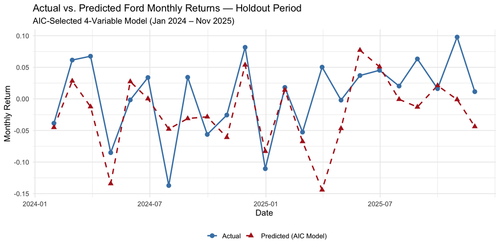

```r
# Convert dates for x-axis
holdout_dates <- as.Date(predict_df$Date, format = "%m/%d/%Y")

plot_df <- data.frame(
  Date      = holdout_dates,
  Actual    = actual_test,
  Predicted = pred_aic
)

ggplot(plot_df, aes(x = Date)) +
  geom_line(aes(y = Actual,    color = "Actual"),                 linewidth = 0.9) +
  geom_line(aes(y = Predicted, color = "Predicted (AIC Model)"),  linewidth = 0.9,
            linetype = "dashed") +
  geom_point(aes(y = Actual,    color = "Actual"),                size = 2.5) +
  geom_point(aes(y = Predicted, color = "Predicted (AIC Model)"), size = 2.5,
             shape = 17) +
  scale_color_manual(
    values = c("Actual" = "steelblue", "Predicted (AIC Model)" = "firebrick")
  ) +
  labs(
    title    = "Actual vs. Predicted Ford Monthly Returns — Holdout Period",
    subtitle = "AIC-Selected 4-Variable Model (Jan 2024 – Nov 2025)",
    x        = "Date",
    y        = "Monthly Return",
    color    = ""
  ) +
  theme_minimal(base_size = 12) +
  theme(legend.position = "bottom")
```

The plot illustrates the directional accuracy of the AIC model during the holdout period. While the model captures broad movements driven by market-wide factors, it understandably struggles to replicate the full magnitude of idiosyncratic Ford-specific return shocks — consistent with the inherent difficulty of individual stock return prediction.

# 8 Final Model Recommendation

Based on the combined evidence from in-sample model selection, diagnostic testing, and out-of-sample evaluation, we recommend the **AIC-Selected 4-Variable Model** as the final specification:

$$\hat{R}^{Ford}_t = \hat{\beta}_0 + \hat{\beta}_1 \cdot \text{DivYield}_t + \hat{\beta}_2 \cdot \text{MktVar}_t + \hat{\beta}_3 \cdot \text{10yYield}_t + \hat{\beta}_4 \cdot \text{ExcessReturn}_t + \varepsilon_t$$

# 9 Conclusion

Overall, the AIC-selected multi-factor regression model represents the best-performing, most statistically sound specification for explaining Ford’s return dynamics within this dataset. Future work could explore time-varying parameter models, rolling-window estimation, or machine learning approaches to further improve out-of-sample accuracy.

# 10 Appendix: Additional Diagnostics

## Regression Diagnostic Plots — AIC Model

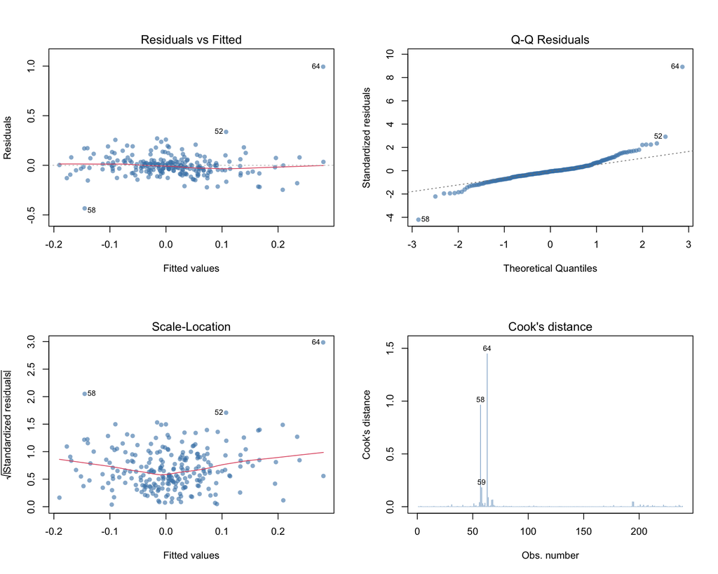

```r
# Base R's built-in diagnostic suite: Residuals vs Fitted, Normal QQ,
# Scale-Location (sqrt standardized residuals), Residuals vs Leverage
par(mfrow = c(2, 2))
plot(AIC_reg,
     which = 1:4,
     col   = adjustcolor("steelblue", alpha.f = 0.6),
     pch   = 16)
```

```r
par(mfrow = c(1, 1))
```

## Holdout Period Predictions — All Models

```r
# Full prediction table for the out-of-sample period
all_preds <- data.frame(
  Date      = predict_df$Date,
  Actual    = round(actual_test, 4),
  Full      = round(pred_full,   4),
  AIC_Model = round(pred_aic,    4),
  CP_Model  = round(pred_cp,     4),
  CAPM      = round(pred_capm,   4)
)

kable(
  all_preds,
  col.names = c("Date", "Actual", "Full Model",
                "AIC Model", "Cp Model", "CAPM"),
  caption   = "Out-of-Sample Monthly Predictions by Model — Jan 2024 to Nov 2025"
) %>%
  kable_styling(bootstrap_options = c("striped", "hover"), full_width = FALSE,
                font_size = 12)
```

Out-of-Sample Monthly Predictions by Model — Jan 2024 to Nov 2025

|  | Date | Actual | Full Model | AIC Model | Cp Model | CAPM |
| --- | --- | --- | --- | --- | --- | --- |
| 241 | 1/31/2024 | -0.0386 | -0.0124 | -0.0451 | -0.0156 | -0.0616 |
| 242 | 2/29/2024 | 0.0614 | 0.0510 | 0.0283 | 0.0455 | -0.0050 |
| 243 | 3/29/2024 | 0.0675 | 0.0075 | -0.0123 | 0.0089 | -0.0376 |
| 244 | 4/30/2024 | -0.0851 | -0.1293 | -0.1341 | -0.1166 | -0.1504 |
| 245 | 5/31/2024 | -0.0016 | 0.0298 | 0.0274 | 0.0383 | -0.0109 |
| 246 | 6/28/2024 | 0.0338 | 0.0207 | 0.0003 | 0.0148 | -0.0311 |
| 247 | 7/31/2024 | -0.1372 | -0.0455 | -0.0478 | -0.0268 | -0.0678 |
| 248 | 8/30/2024 | 0.0342 | -0.0322 | -0.0311 | -0.0096 | -0.0502 |
| 249 | 9/30/2024 | -0.0563 | -0.0274 | -0.0284 | -0.0096 | -0.0474 |
| 250 | 10/31/2024 | -0.0256 | -0.0479 | -0.0609 | -0.0623 | -0.0922 |
| 251 | 11/29/2024 | 0.0816 | 0.0764 | 0.0537 | 0.0566 | 0.0159 |
| 252 | 12/31/2024 | -0.1105 | -0.0758 | -0.0830 | -0.0850 | -0.1092 |
| 253 | 1/31/2025 | 0.0182 | 0.0134 | 0.0140 | 0.0041 | -0.0268 |
| 254 | 2/28/2025 | -0.0526 | -0.0752 | -0.0675 | -0.0711 | -0.0904 |
| 255 | 3/31/2025 | 0.0503 | -0.1731 | -0.1441 | -0.1471 | -0.1580 |
| 256 | 4/30/2025 | -0.0020 | -0.0867 | -0.0468 | -0.0634 | -0.0798 |
| 257 | 5/30/2025 | 0.0370 | 0.0807 | 0.0770 | 0.0520 | 0.0278 |
| 258 | 6/30/2025 | 0.0453 | 0.0361 | 0.0508 | 0.0330 | 0.0112 |
| 259 | 7/31/2025 | 0.0203 | 0.0118 | -0.0007 | -0.0164 | -0.0344 |
| 260 | 8/29/2025 | 0.0632 | -0.0353 | -0.0129 | -0.0226 | -0.0398 |
| 261 | 9/30/2025 | 0.0161 | 0.0126 | 0.0210 | 0.0088 | -0.0110 |
| 262 | 10/31/2025 | 0.0978 | -0.0011 | -0.0011 | -0.0113 | -0.0294 |
| 263 | 11/28/2025 | 0.0114 | -0.0588 | -0.0438 | -0.0488 | -0.0609 |

## Full Model Coefficient Estimates

```r
full_coef_df           <- as.data.frame(summary(big_reg)$coefficients)
colnames(full_coef_df) <- c("Estimate", "Std. Error", "t-value", "p-value")

kable(round(full_coef_df, 4),
      caption = "Full Model (11 Variables) — Coefficient Estimates") %>%
  kable_styling(bootstrap_options = c("striped", "hover"), full_width = FALSE)
```

Full Model (11 Variables) — Coefficient Estimates

|  | Estimate | Std. Error | t-value | p-value |
| --- | --- | --- | --- | --- |
| (Intercept) | -0.2031 | 0.1599 | -1.2700 | 0.2054 |
| FIBOR | 0.9464 | 0.9393 | 1.0075 | 0.3147 |
| Confidence.Index | 0.0002 | 0.0007 | 0.2342 | 0.8151 |
| X10y_treasury | 1.4104 | 1.2845 | 1.0980 | 0.2734 |
| div_to_price | 0.2870 | 0.2081 | 1.3787 | 0.1693 |
| earnings_to_price | 2.4499 | 3.1938 | 0.7671 | 0.4438 |
| book_to_market | -0.2831 | 0.3607 | -0.7849 | 0.4333 |
| gold_return | -0.0020 | 0.1729 | -0.0113 | 0.9910 |
| oil_return | 0.0669 | 0.0750 | 0.8919 | 0.3734 |
| dol_eu_change | -0.4643 | 0.3534 | -1.3138 | 0.1902 |
| excess_return | 2.0212 | 0.2436 | 8.2986 | 0.0000 |
| market_variance | 0.4072 | 0.2409 | 1.6900 | 0.0924 |